# NFL Stats Predicted

Rich L

April 10, 2017

# Goal of analysis

The goal of this capstone project was to set a baseline linear regression for predicting NFL statistics. The use of the analysis would be to project player performance and see if the team I am working with needs to consider making adjustments given various factors of the upcoming game/season.

Data from http://armchairanalysis.com/data.php

# Data and relationships between fields

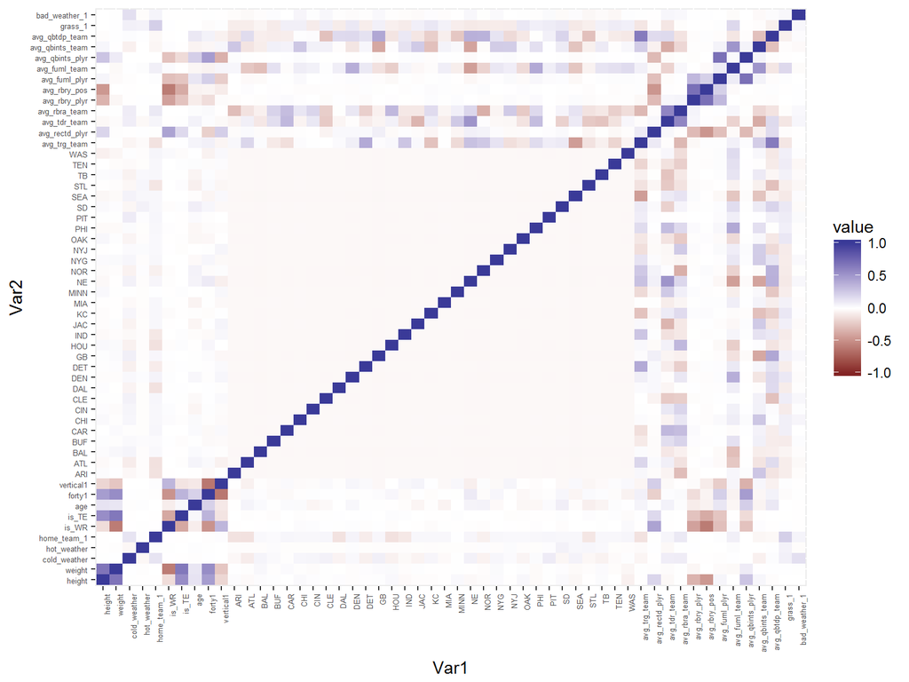

Originally we had 86 fields on which we were going to evaluate. We did a test for correlation, and removed any fields with a correlation above .8

# Receiving Yards

Summary of receiving yards

```
##
## Call:
## lm(formula = recy ~ weight + cold_weather + is_WR + is_TE + age +
##     forty1 + ARI + ATL + BAL + CAR + CHI + CIN + CLE + DET +
##     HOU + IND + KC + MIA + MINN + NYG + OAK + PHI + PIT + SD +
##     STL + TB + TEN + WAS + avg_rectd_plyr + avg_rbry_plyr + avg_rbry_pos +
##     grass_1 + bad_weather_1, data = trainTransformed)
##
## Residuals:
##     Min      1Q  Median      3Q     Max
## -3.4190 -0.4334 -0.0969  0.2295  7.4922
##
## Coefficients:
##                  Estimate Std. Error t value Pr(>|t|)
## (Intercept)    -9.540e-16  4.826e-03   0.000 1.000000
## weight         -2.477e-02  7.941e-03  -3.119 0.001818 **
## cold_weather   -1.857e-02  5.000e-03  -3.714 0.000204 ***
## is_WR           2.250e-01  1.522e-02  14.791  < 2e-16 ***
## is_TE           1.067e-01  1.120e-02   9.528  < 2e-16 ***
## age             2.359e-02  5.087e-03   4.637 3.54e-06 ***
## forty1         -2.074e-02  7.394e-03  -2.805 0.005040 **
## ARI             1.776e-02  5.002e-03   3.550 0.000386 ***
## ATL             1.752e-02  5.014e-03   3.493 0.000478 ***
## BAL             1.556e-02  5.007e-03   3.108 0.001882 **
## CAR             1.198e-02  5.019e-03   2.387 0.017013 *
## CHI             1.595e-02  5.000e-03   3.190 0.001422 **
## CIN             1.293e-02  4.998e-03   2.586 0.009716 **
## CLE             3.043e-02  5.037e-03   6.041 1.55e-09 ***
## DET             1.542e-02  4.994e-03   3.087 0.002022 **
## HOU             2.054e-02  5.009e-03   4.100 4.14e-05 ***
## IND             1.281e-02  4.996e-03   2.565 0.010336 *
## KC              1.419e-02  5.040e-03   2.815 0.004876 **
## MIA             1.479e-02  5.004e-03   2.955 0.003125 **
## MINN            1.456e-02  4.997e-03   2.914 0.003575 **
## NYG             1.264e-02  5.003e-03   2.526 0.011536 *
## OAK             1.535e-02  5.062e-03   3.032 0.002429 **
## PHI             1.896e-02  4.996e-03   3.796 0.000148 ***
## PIT             2.438e-02  5.029e-03   4.848 1.25e-06 ***
## SD              1.137e-02  5.037e-03   2.258 0.023953 *
## STL             1.455e-02  5.016e-03   2.901 0.003721 **
## TB              9.935e-03  5.022e-03   1.978 0.047929 *
## TEN             1.145e-02  5.026e-03   2.279 0.022686 *
## WAS             2.000e-02  5.021e-03   3.983 6.81e-05 ***
## avg_rectd_plyr  5.218e-01  6.177e-03  84.469  < 2e-16 ***
## avg_rbry_plyr   5.835e-02  6.991e-03   8.347  < 2e-16 ***
## avg_rbry_pos    8.807e-02  1.341e-02   6.567 5.21e-11 ***
## grass_1        -1.651e-02  5.255e-03  -3.141 0.001684 **
## bad_weather_1  -9.916e-03  4.901e-03  -2.023 0.043034 *
## ---
## Signif. codes:  0 '***' 0.001 '**' 0.01 '*' 0.05 '.' 0.1 ' ' 1
##
## Residual standard error: 0.8001 on 27450 degrees of freedom
## Multiple R-squared:  0.3606, Adjusted R-squared:  0.3598
## F-statistic: 469.1 on 33 and 27450 DF,  p-value: < 2.2e-16
```

The R-squared is low for this analysis. This is intuitive because of the nature of receiving. The ball is never guaranteed to be in the player’s hands, and there are up to 5 other players on the field at a time vying to have the ball thrown to them. Another type of analysis is needed.

# Plots of receiving yards

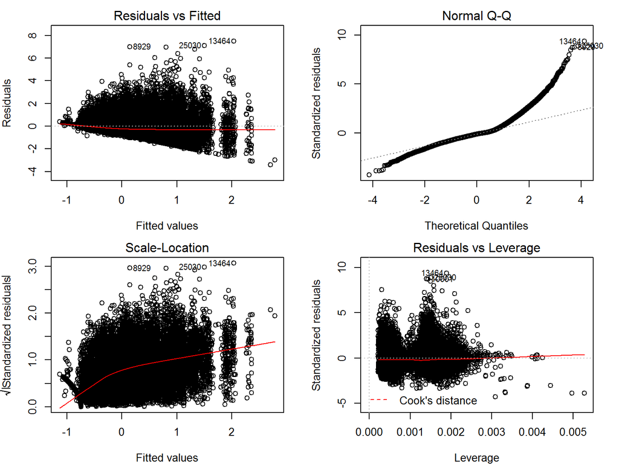

# Receptions

```
##
## Call:
## lm(formula = rec ~ height + weight + cold_weather + home_team_1 +
##     is_WR + is_TE + age + vertical1 + ARI + ATL + BAL + BUF +
##     CAR + CHI + CIN + CLE + DAL + DEN + DET + HOU + IND + JAC +
##     KC + MIA + MINN + NE + NOR + NYG + NYJ + OAK + PHI + PIT +
##     SD + STL + TB + TEN + WAS + avg_rectd_plyr + avg_rbry_plyr +
##     avg_rbry_pos + avg_fuml_plyr + avg_qbints_plyr + grass_1 +
##     bad_weather_1, data = trainTransformedrec)
##
## Residuals:
##     Min      1Q  Median      3Q     Max
## -3.2886 -0.5126 -0.0901  0.3257  6.4007
##
## Coefficients:
##                   Estimate Std. Error t value Pr(>|t|)
## (Intercept)     -2.165e-15  4.867e-03   0.000 1.000000
## height          -3.970e-02  9.523e-03  -4.169 3.07e-05 ***
## weight          -3.388e-02  1.022e-02  -3.314 0.000921 ***
## cold_weather    -1.673e-02  5.098e-03  -3.283 0.001029 **
## home_team_1     -1.104e-02  5.295e-03  -2.085 0.037101 *
## is_WR            2.802e-01  2.304e-02  12.163  < 2e-16 ***
## is_TE            2.250e-01  1.829e-02  12.297  < 2e-16 ***
## age              4.633e-02  5.160e-03   8.979  < 2e-16 ***
## vertical1       -1.646e-02  5.622e-03  -2.927 0.003420 **
## ARI              2.880e-02  5.579e-03   5.162 2.46e-07 ***
## ATL              3.358e-02  5.613e-03   5.982 2.23e-09 ***
## BAL              3.600e-02  5.547e-03   6.489 8.81e-11 ***
## BUF              1.912e-02  5.519e-03   3.465 0.000530 ***
## CAR              1.484e-02  5.514e-03   2.692 0.007114 **
## CHI              3.226e-02  5.488e-03   5.878 4.20e-09 ***
## CIN              3.330e-02  5.523e-03   6.031 1.66e-09 ***
## CLE              4.599e-02  5.529e-03   8.318  < 2e-16 ***
## DAL              1.824e-02  5.577e-03   3.271 0.001075 **
## DEN              1.259e-02  5.553e-03   2.266 0.023442 *
## DET              3.592e-02  5.545e-03   6.478 9.47e-11 ***
## HOU              3.861e-02  5.606e-03   6.887 5.81e-12 ***
## IND              3.175e-02  5.566e-03   5.705 1.18e-08 ***
## JAC              3.318e-02  5.511e-03   6.022 1.75e-09 ***
## KC               3.321e-02  5.540e-03   5.994 2.08e-09 ***
```

[output cut: 12 more lines]

```
## TEN              2.177e-02  5.532e-03   3.934 8.36e-05 ***
## WAS              3.135e-02  5.532e-03   5.667 1.47e-08 ***
## avg_rectd_plyr   5.226e-01  6.321e-03  82.685  < 2e-16 ***
## avg_rbry_plyr    1.246e-01  7.455e-03  16.709  < 2e-16 ***
## avg_rbry_pos     1.735e-01  2.127e-02   8.157 3.57e-16 ***
## avg_fuml_plyr    2.664e-02  7.796e-03   3.417 0.000635 ***
## avg_qbints_plyr -4.345e-02  1.112e-02  -3.908 9.34e-05 ***
## grass_1         -1.293e-02  5.522e-03  -2.341 0.019238 *
## bad_weather_1   -9.995e-03  4.951e-03  -2.019 0.043506 *
## ---
## Signif. codes:  0 '***' 0.001 '**' 0.01 '*' 0.05 '.' 0.1 ' ' 1
##
## Residual standard error: 0.8069 on 27439 degrees of freedom
## Multiple R-squared:  0.3499, Adjusted R-squared:  0.3489
## F-statistic: 335.7 on 44 and 27439 DF,  p-value: < 2.2e-16
```

The adjusted R2 is not very strong (0.3489), this is due to the same problem in forecasting that we had in receiving yards.

# Plots of receptions

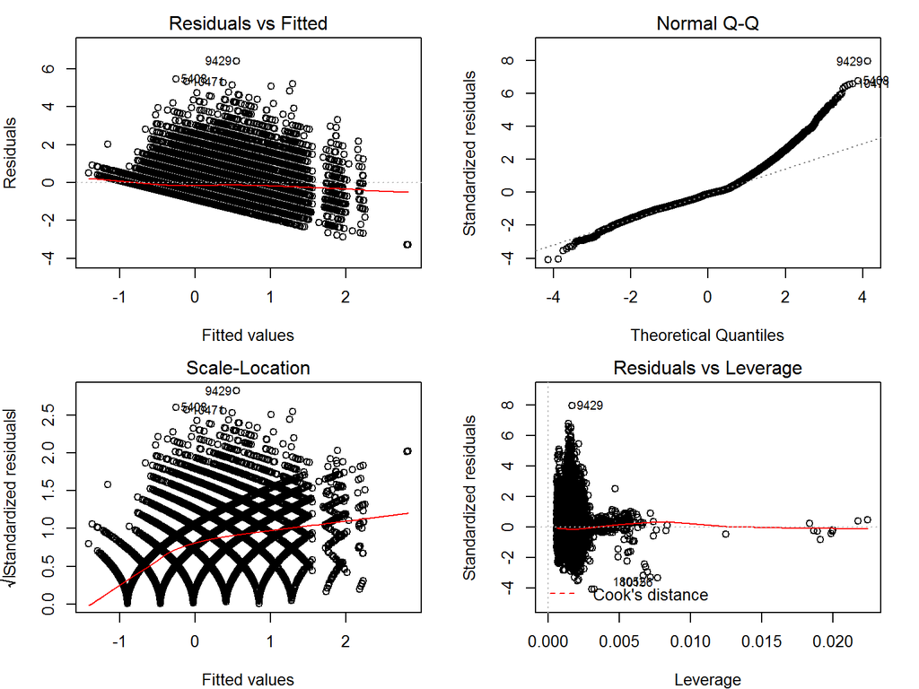

# Targets

```
##
## Call:
## lm(formula = trg ~ weight + home_team_1 + is_WR + is_TE + age +
##     ARI + ATL + BAL + BUF + CAR + CHI + CIN + CLE + DET + HOU +
##     IND + JAC + KC + MIA + MINN + NYG + NYJ + OAK + PHI + PIT +
##     SD + STL + TB + TEN + WAS + avg_rectd_plyr + avg_rbry_plyr +
##     avg_rbry_pos + avg_fuml_plyr + avg_qbints_plyr, data = trainTransformedtrg)
##
## Residuals:
##     Min      1Q  Median      3Q     Max
## -3.6560 -0.4651 -0.0769  0.3096  5.3423
##
## Coefficients:
##                   Estimate Std. Error t value Pr(>|t|)
## (Intercept)      1.025e-15  4.535e-03   0.000   1.0000
## weight          -4.540e-02  7.205e-03  -6.302 2.99e-10 ***
## home_team_1     -1.943e-02  4.784e-03  -4.062 4.89e-05 ***
## is_WR            3.386e-01  2.115e-02  16.007  < 2e-16 ***
## is_TE            2.079e-01  1.690e-02  12.299  < 2e-16 ***
## age              4.699e-02  4.791e-03   9.807  < 2e-16 ***
## ARI              3.741e-02  4.806e-03   7.785 7.23e-15 ***
## ATL              2.272e-02  4.801e-03   4.732 2.24e-06 ***
## BAL              3.428e-02  4.792e-03   7.153 8.70e-13 ***
## BUF              2.325e-02  4.763e-03   4.881 1.06e-06 ***
## CAR              1.924e-02  4.772e-03   4.033 5.52e-05 ***
## CHI              2.367e-02  4.759e-03   4.974 6.60e-07 ***
## CIN              2.812e-02  4.773e-03   5.891 3.88e-09 ***
## CLE              5.048e-02  4.790e-03  10.537  < 2e-16 ***
## DET              3.296e-02  4.773e-03   6.906 5.08e-12 ***
## HOU              3.876e-02  4.818e-03   8.045 8.96e-16 ***
## IND              3.616e-02  4.789e-03   7.550 4.48e-14 ***
## JAC              4.041e-02  4.771e-03   8.471  < 2e-16 ***
## KC               2.806e-02  4.779e-03   5.871 4.38e-09 ***
## MIA              2.968e-02  4.768e-03   6.225 4.90e-10 ***
## MINN             3.530e-02  4.773e-03   7.395 1.45e-13 ***
## NYG              2.477e-02  4.783e-03   5.178 2.26e-07 ***
## NYJ              2.581e-02  4.779e-03   5.401 6.69e-08 ***
## OAK              3.177e-02  4.792e-03   6.630 3.42e-11 ***
## PHI              2.930e-02  4.761e-03   6.154 7.67e-10 ***
## PIT              2.422e-02  4.768e-03   5.080 3.81e-07 ***
## SD               1.200e-02  4.759e-03   2.522   0.0117 *
## STL              3.569e-02  4.815e-03   7.414 1.26e-13 ***
## TB               2.117e-02  4.781e-03   4.428 9.55e-06 ***
## TEN              2.283e-02  4.775e-03   4.781 1.76e-06 ***
## WAS              2.358e-02  4.779e-03   4.934 8.10e-07 ***
## avg_rectd_plyr   5.495e-01  5.822e-03  94.393  < 2e-16 ***
## avg_rbry_plyr    1.043e-01  6.930e-03  15.055  < 2e-16 ***
## avg_rbry_pos     1.657e-01  1.912e-02   8.667  < 2e-16 ***
## avg_fuml_plyr    1.693e-02  7.251e-03   2.335   0.0196 *
## avg_qbints_plyr -4.206e-02  1.013e-02  -4.150 3.33e-05 ***
## ---
## Signif. codes:  0 '***' 0.001 '**' 0.01 '*' 0.05 '.' 0.1 ' ' 1
##
## Residual standard error: 0.7518 on 27448 degrees of freedom
## Multiple R-squared:  0.4355, Adjusted R-squared:  0.4348
## F-statistic: 605.1 on 35 and 27448 DF,  p-value: < 2.2e-16
```

# Plots for Targets

[figure not shown]

# Receiving TD’s

```
##
## Call:
## lm(formula = tdrec ~ avg_rectd_plyr + avg_qbtdp_team, data = trainTransformedtdrec)
##
## Residuals:
##     Min      1Q  Median      3Q     Max
## -1.9645 -0.4372 -0.1334  0.0043  9.0779
##
## Coefficients:
##                  Estimate Std. Error t value Pr(>|t|)
## (Intercept)    -5.203e-16  5.562e-03   0.000  1.00000
## avg_rectd_plyr  3.844e-01  5.638e-03  68.179  < 2e-16 ***
## avg_qbtdp_team  1.484e-02  5.638e-03   2.632  0.00851 **
## ---
## Signif. codes:  0 '***' 0.001 '**' 0.01 '*' 0.05 '.' 0.1 ' ' 1
##
## Residual standard error: 0.9221 on 27481 degrees of freedom
## Multiple R-squared:  0.1499, Adjusted R-squared:  0.1498
## F-statistic:  2422 on 2 and 27481 DF,  p-value: < 2.2e-16
```

R-squared is low for this statistic. Touchdowns are much more random in nature that receptions or receiving yards. We should look for other ways to predict this. This stat relies heavily on the average TD’s the player being analyzed usually scores.

# Plots for receiving TD’s

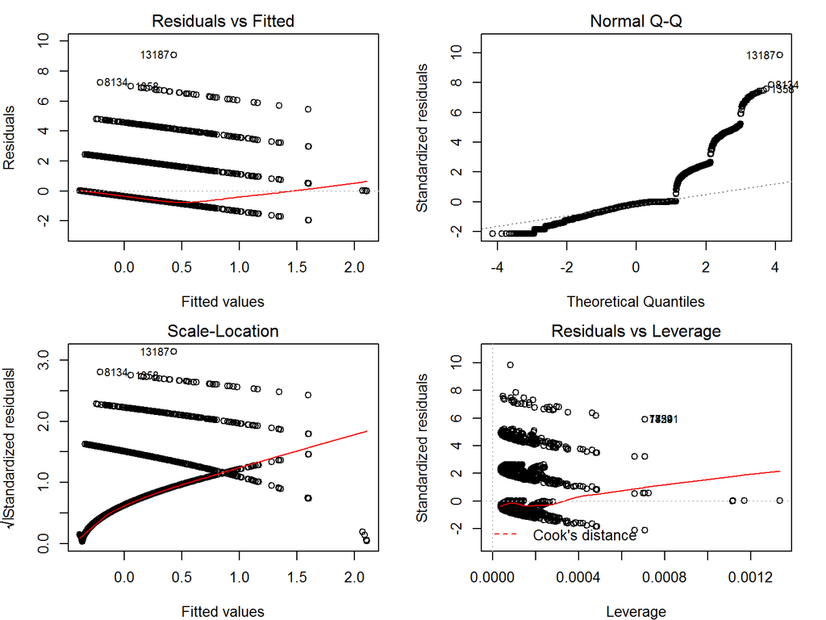

# Passing yards

```
##
## Call:
## lm(formula = py ~ height + weight + cold_weather + is_WR + is_TE +
##     age + forty1 + ARI + BUF + CAR + CHI + CIN + CLE + GB + HOU +
##     IND + JAC + MIA + MINN + NE + NYG + NYJ + OAK + STL + TB +
##     TEN + avg_rectd_plyr + avg_rbry_pos + avg_fuml_plyr + avg_qbints_plyr +
##     bad_weather_1, data = trainTransformedpy)
##
## Residuals:
##     Min      1Q  Median      3Q     Max
## -7.4843 -0.0522 -0.0029  0.0498  4.6501
##
## Coefficients:
##                   Estimate Std. Error t value Pr(>|t|)
## (Intercept)      1.728e-15  2.700e-03   0.000 1.000000
## height           5.226e-02  5.250e-03   9.955  < 2e-16 ***
## weight          -5.096e-02  5.785e-03  -8.809  < 2e-16 ***
## cold_weather    -1.228e-02  2.779e-03  -4.419 9.97e-06 ***
## is_WR           -3.681e-01  1.307e-02 -28.166  < 2e-16 ***
## is_TE           -2.951e-01  1.024e-02 -28.824  < 2e-16 ***
## age              2.596e-02  2.853e-03   9.102  < 2e-16 ***
## forty1           1.527e-02  4.138e-03   3.691 0.000224 ***
## ARI             -2.164e-02  2.765e-03  -7.826 5.23e-15 ***
## BUF             -1.033e-02  2.764e-03  -3.738 0.000186 ***
## CAR             -9.436e-03  2.763e-03  -3.415 0.000638 ***
## CHI             -1.920e-02  2.764e-03  -6.946 3.83e-12 ***
## CIN             -8.497e-03  2.769e-03  -3.068 0.002154 **
## CLE             -1.015e-02  2.775e-03  -3.660 0.000253 ***
## GB               1.655e-02  2.784e-03   5.944 2.81e-09 ***
## HOU             -9.623e-03  2.773e-03  -3.471 0.000520 ***
## IND             -7.114e-03  2.763e-03  -2.574 0.010048 *
## JAC             -2.075e-02  2.769e-03  -7.494 6.87e-14 ***
## MIA             -9.363e-03  2.763e-03  -3.389 0.000703 ***
## MINN            -1.690e-02  2.768e-03  -6.107 1.03e-09 ***
## NE               2.069e-02  2.816e-03   7.347 2.08e-13 ***
## NYG             -1.027e-02  2.774e-03  -3.702 0.000214 ***
## NYJ             -2.356e-02  2.763e-03  -8.527  < 2e-16 ***
## OAK             -7.993e-03  2.783e-03  -2.872 0.004084 **
## STL             -9.680e-03  2.776e-03  -3.487 0.000490 ***
## TB              -1.007e-02  2.771e-03  -3.633 0.000281 ***
## TEN             -1.460e-02  2.763e-03  -5.283 1.28e-07 ***
## avg_rectd_plyr  -2.098e-02  3.497e-03  -6.000 2.00e-09 ***
## avg_rbry_pos    -3.204e-01  1.177e-02 -27.236  < 2e-16 ***
## avg_fuml_plyr    2.660e-02  4.037e-03   6.589 4.50e-11 ***
## avg_qbints_plyr  6.955e-01  6.095e-03 114.105  < 2e-16 ***
## bad_weather_1   -7.448e-03  2.741e-03  -2.717 0.006583 **
## ---
## Signif. codes:  0 '***' 0.001 '**' 0.01 '*' 0.05 '.' 0.1 ' ' 1
##
## Residual standard error: 0.4476 on 27452 degrees of freedom
## Multiple R-squared:  0.7999, Adjusted R-squared:  0.7997
## F-statistic:  3540 on 31 and 27452 DF,  p-value: < 2.2e-16
```

Passing yards seem to be a much better stat to predict with linear regression. This is intuitive given that there is usually only one QB. He throws the ball 100% for his team. His team usually invests heavily in him. So the frequency is typically there, and the longevity is there too.

# Plots for passing yards

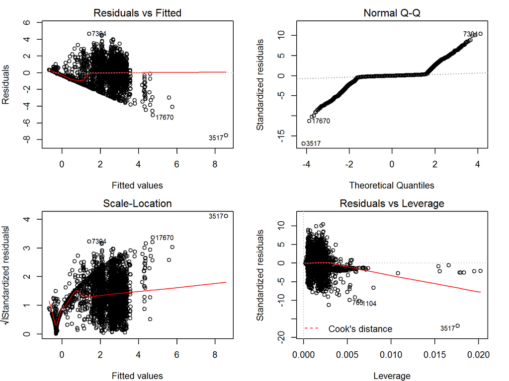

# Pass completions

```
##
## Call:
## lm(formula = pc ~ height + weight + cold_weather + is_WR + is_TE +
##     age + forty1 + ARI + BUF + CAR + CHI + CLE + GB + HOU + IND +
##     JAC + MINN + NE + NOR + NYG + NYJ + OAK + SD + TB + TEN +
##     avg_rectd_plyr + avg_rbry_pos + avg_fuml_plyr + avg_qbints_plyr +
##     bad_weather_1, data = trainTransformedpc)
##
## Residuals:
##     Min      1Q  Median      3Q     Max
## -7.3532 -0.0521 -0.0022  0.0481  4.2184
##
## Coefficients:
##                   Estimate Std. Error t value Pr(>|t|)
## (Intercept)      1.001e-15  2.623e-03   0.000 1.000000
## height           5.404e-02  5.104e-03  10.589  < 2e-16 ***
## weight          -5.657e-02  5.623e-03 -10.061  < 2e-16 ***
## cold_weather    -1.136e-02  2.701e-03  -4.206 2.61e-05 ***
## is_WR           -3.777e-01  1.270e-02 -29.740  < 2e-16 ***
## is_TE           -3.017e-01  9.949e-03 -30.322  < 2e-16 ***
## age              2.783e-02  2.764e-03  10.067  < 2e-16 ***
## forty1           1.953e-02  4.020e-03   4.859 1.19e-06 ***
## ARI             -2.067e-02  2.680e-03  -7.713 1.27e-14 ***
## BUF             -7.456e-03  2.678e-03  -2.784 0.005371 **
## CAR             -1.184e-02  2.680e-03  -4.416 1.01e-05 ***
## CHI             -1.826e-02  2.681e-03  -6.810 9.95e-12 ***
## CLE             -6.644e-03  2.685e-03  -2.474 0.013354 *
## GB               1.690e-02  2.699e-03   6.262 3.85e-10 ***
## HOU             -7.332e-03  2.687e-03  -2.729 0.006358 **
## IND             -5.767e-03  2.679e-03  -2.153 0.031334 *
## JAC             -1.675e-02  2.682e-03  -6.244 4.34e-10 ***
## MINN            -1.180e-02  2.681e-03  -4.401 1.08e-05 ***
## NE               1.984e-02  2.733e-03   7.259 4.00e-13 ***
## NOR              1.043e-02  2.700e-03   3.865 0.000112 ***
## NYG             -9.853e-03  2.687e-03  -3.667 0.000246 ***
## NYJ             -2.297e-02  2.677e-03  -8.582  < 2e-16 ***
## OAK             -5.847e-03  2.696e-03  -2.169 0.030091 *
## SD              -7.435e-03  2.689e-03  -2.765 0.005697 **
## TB              -1.001e-02  2.683e-03  -3.731 0.000191 ***
## TEN             -1.464e-02  2.679e-03  -5.467 4.63e-08 ***
## avg_rectd_plyr  -1.933e-02  3.401e-03  -5.685 1.32e-08 ***
## avg_rbry_pos    -3.257e-01  1.144e-02 -28.466  < 2e-16 ***
## avg_fuml_plyr    2.257e-02  3.925e-03   5.750 9.03e-09 ***
## avg_qbints_plyr  6.987e-01  5.924e-03 117.953  < 2e-16 ***
## bad_weather_1   -7.204e-03  2.662e-03  -2.706 0.006809 **
## ---
## Signif. codes:  0 '***' 0.001 '**' 0.01 '*' 0.05 '.' 0.1 ' ' 1
##
## Residual standard error: 0.4349 on 27453 degrees of freedom
## Multiple R-squared:  0.8111, Adjusted R-squared:  0.8109
## F-statistic:  3929 on 30 and 27453 DF,  p-value: < 2.2e-16
```

# Plots for pass completions

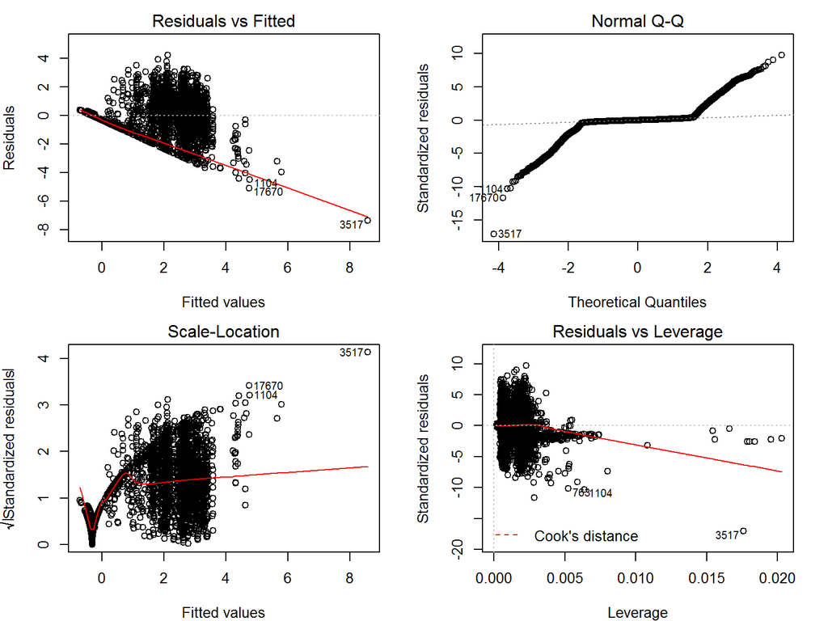

# Interceptions

```
##
## Call:
## lm(formula = ints ~ avg_qbints_plyr, data = trainTransformedints)
##
## Residuals:
##     Min      1Q  Median      3Q     Max
## -4.0750 -0.0018 -0.0018 -0.0018 11.2261
##
## Coefficients:
##                   Estimate Std. Error t value Pr(>|t|)
## (Intercept)     -2.104e-15  4.606e-03     0.0        1
## avg_qbints_plyr  6.457e-01  4.606e-03   140.2   <2e-16 ***
## ---
## Signif. codes:  0 '***' 0.001 '**' 0.01 '*' 0.05 '.' 0.1 ' ' 1
##
## Residual standard error: 0.7636 on 27482 degrees of freedom
## Multiple R-squared:  0.417,  Adjusted R-squared:  0.4169
## F-statistic: 1.965e+04 on 1 and 27482 DF,  p-value: < 2.2e-16
```

# Plots for interceptions

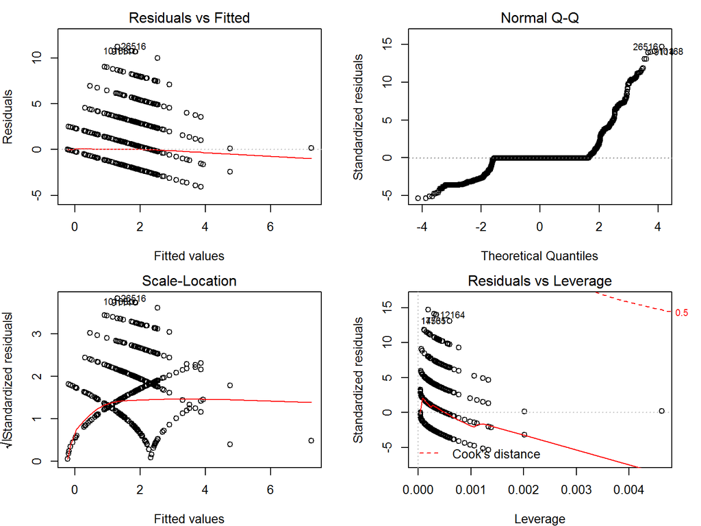

# Pass Attempts

```
##
## Call:
## lm(formula = pa ~ height + weight + cold_weather + is_WR + is_TE +
##     age + forty1 + ARI + BUF + CAR + CHI + CIN + GB + HOU + JAC +
##     MIA + MINN + NE + NYG + NYJ + SD + TB + TEN + avg_rectd_plyr +
##     avg_rbry_pos + avg_fuml_plyr + avg_qbints_plyr, data = trainTransformedpa)
##
## Residuals:
##     Min      1Q  Median      3Q     Max
## -6.8806 -0.0428 -0.0040  0.0401  3.7496
##
## Coefficients:
##                   Estimate Std. Error t value Pr(>|t|)
## (Intercept)      2.991e-15  2.489e-03   0.000 1.000000
## height           5.292e-02  4.826e-03  10.965  < 2e-16 ***
## weight          -4.857e-02  5.336e-03  -9.102  < 2e-16 ***
## cold_weather    -7.901e-03  2.531e-03  -3.122 0.001796 **
## is_WR           -3.792e-01  1.205e-02 -31.459  < 2e-16 ***
## is_TE           -3.053e-01  9.441e-03 -32.333  < 2e-16 ***
## age              1.727e-02  2.623e-03   6.582 4.72e-11 ***
## forty1           1.433e-02  3.812e-03   3.760 0.000170 ***
## ARI             -1.722e-02  2.530e-03  -6.806 1.03e-11 ***
## BUF             -6.601e-03  2.530e-03  -2.609 0.009077 **
## CAR             -8.695e-03  2.531e-03  -3.436 0.000591 ***
## CHI             -1.920e-02  2.532e-03  -7.584 3.47e-14 ***
## CIN             -5.122e-03  2.534e-03  -2.021 0.043263 *
## GB               1.507e-02  2.550e-03   5.911 3.44e-09 ***
## HOU             -5.345e-03  2.538e-03  -2.106 0.035193 *
## JAC             -1.344e-02  2.534e-03  -5.301 1.16e-07 ***
## MIA             -6.816e-03  2.529e-03  -2.695 0.007042 **
## MINN            -1.223e-02  2.533e-03  -4.830 1.37e-06 ***
## NE               1.886e-02  2.584e-03   7.301 2.93e-13 ***
## NYG             -1.010e-02  2.539e-03  -3.979 6.94e-05 ***
## NYJ             -1.965e-02  2.529e-03  -7.771 8.03e-15 ***
## SD              -9.025e-03  2.540e-03  -3.553 0.000381 ***
## TB              -8.012e-03  2.536e-03  -3.159 0.001583 **
## TEN             -1.300e-02  2.529e-03  -5.141 2.76e-07 ***
## avg_rectd_plyr  -1.707e-02  3.207e-03  -5.324 1.03e-07 ***
## avg_rbry_pos    -3.288e-01  1.086e-02 -30.272  < 2e-16 ***
## avg_fuml_plyr    2.567e-02  3.719e-03   6.902 5.23e-12 ***
## avg_qbints_plyr  7.118e-01  5.615e-03 126.775  < 2e-16 ***
## ---
## Signif. codes:  0 '***' 0.001 '**' 0.01 '*' 0.05 '.' 0.1 ' ' 1
##
## Residual standard error: 0.4127 on 27456 degrees of freedom
## Multiple R-squared:  0.8298, Adjusted R-squared:  0.8297
## F-statistic:  4959 on 27 and 27456 DF,  p-value: < 2.2e-16
```

# Plots for pass attempts

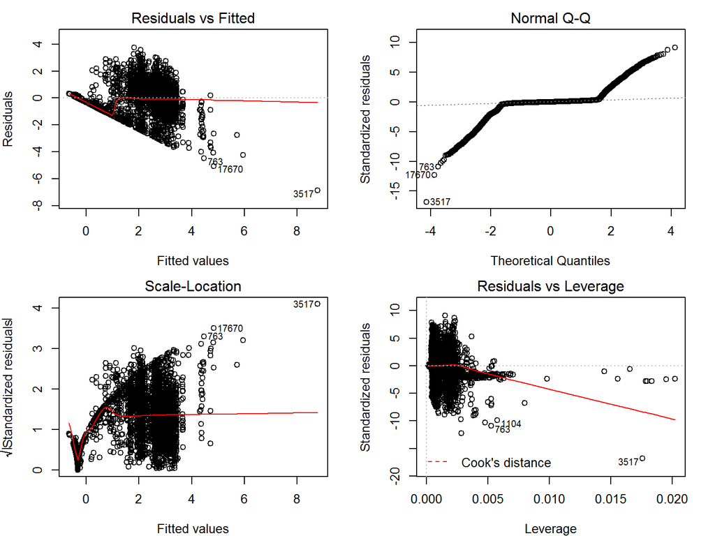

# Rushing yards

```
##
## Call:
## lm(formula = ry ~ cold_weather + age + avg_rbry_plyr, data = trainTransformedry)
##
## Residuals:
##     Min      1Q  Median      3Q     Max
## -3.4479 -0.0808 -0.0098  0.0180  7.1569
##
## Coefficients:
##                 Estimate Std. Error t value Pr(>|t|)
## (Intercept)    2.339e-14  3.911e-03   0.000 1.000000
## cold_weather   1.403e-02  3.912e-03   3.587 0.000336 ***
## age           -1.606e-02  3.925e-03  -4.091  4.3e-05 ***
## avg_rbry_plyr  7.596e-01  3.925e-03 193.517  < 2e-16 ***
## ---
## Signif. codes:  0 '***' 0.001 '**' 0.01 '*' 0.05 '.' 0.1 ' ' 1
##
## Residual standard error: 0.6485 on 27480 degrees of freedom
## Multiple R-squared:  0.5796, Adjusted R-squared:  0.5795
## F-statistic: 1.263e+04 on 3 and 27480 DF,  p-value: < 2.2e-16
```

Rushing is also very much like passing. Usually there is a main running back who gets the ball frequently. It is also widely known that running back’s productiondecline significantly with age. I was glad to see the model accounted for this as well.

# Plots for rushing yards

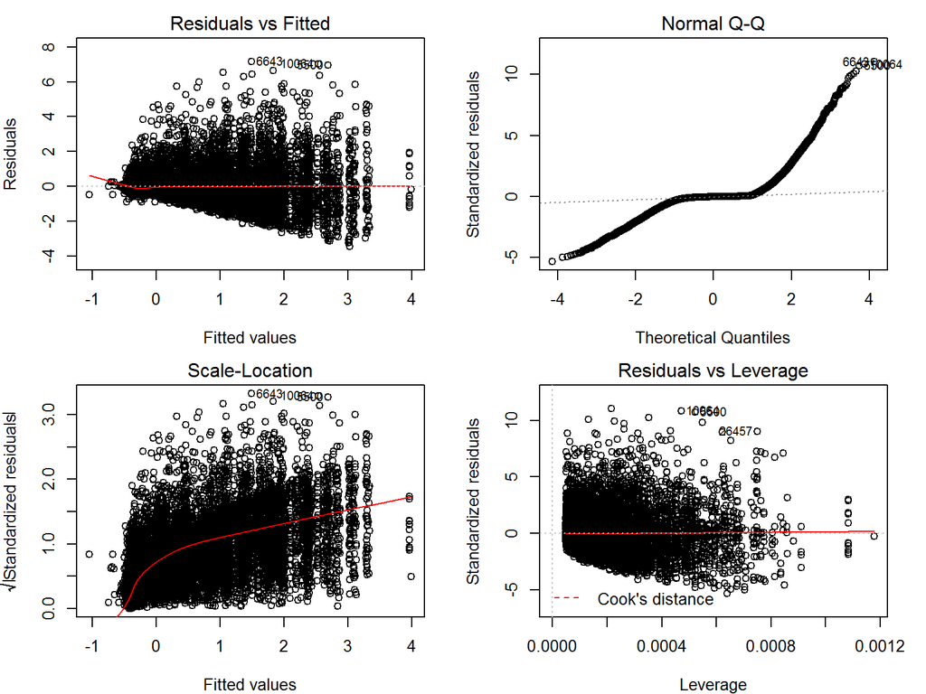